# Lecture 2: Basic Computation and Stats

### Dollar Sign

And in many contexts, the dollar sign is the most useful way of subsetting. When you want to take a single column of a dataframe, for example, and use it as a vector, this is the way to do it.

Let’s say we want to just pull the number of treasure chests each pirate has, out of the `pirates` dataset.

```r
pirates$tchests  #this is just that column of data.
```

[output not shown]

[output cut: 44 more lines]

```r
#And a single column of data is, by definition, a vector.

#we could then summarize this or plot it, or whatever...
summary(pirates$tchests)
```

```
##    Min. 1st Qu.  Median    Mean 3rd Qu.    Max.
##    0.00    6.00   15.00   22.69   30.00  147.00
```

#A Worked Example

Here’s why subsetting is useful:

Take the sample dataset (already installed) called *WorldPhones* (the number of telephones over time, by geography).

```r
WorldPhones
```

```
##      N.Amer Europe Asia S.Amer Oceania Africa Mid.Amer
## 1951  45939  21574 2876   1815    1646     89      555
## 1956  60423  29990 4708   2568    2366   1411      733
## 1957  64721  32510 5230   2695    2526   1546      773
## 1958  68484  35218 6662   2845    2691   1663      836
## 1959  71799  37598 6856   3000    2868   1769      911
## 1960  76036  40341 8220   3145    3054   1905     1008
## 1961  79831  43173 9053   3338    3224   2005     1076
```

Let’s select and plot the growth of phone service in the Americas (overall). First, we select the columns we care about:

```r
(Amers <- WorldPhones[,c("N.Amer", "S.Amer", "Mid.Amer")])
```

```
##      N.Amer S.Amer Mid.Amer
## 1951  45939   1815      555
## 1956  60423   2568      733
## 1957  64721   2695      773
## 1958  68484   2845      836
## 1959  71799   3000      911
## 1960  76036   3145     1008
## 1961  79831   3338     1076
```

Note a few things here:

- First, you have to tell R that you want all rows for the selected columns. In general, we index dataframes by [rows, columns]. To select all rows for only some columns, you don’t put a value in the rows spot, so it looks like this: [,columns].
- Second, we selected columns by column name. We could have put in `WorldPhones[,c(1,4,7)]`, indexing by number, and gotten the same result.
- Third, we stored the subset dataframe in a variable called *Amers*. And we printed the results to the screen at the same time by using a little trick: the whole expression was in parentheses.
- Forth, we created a vector `c("N.Amer", "S.Amer", "Mid.Amer")` to tell **R** we wanted to pull multiple columns from the dataset. Most times you are giving **R** a set of things, you are going to use this notation. Here, it’s a vector of character strings… the names of the columns.

Now we want to sum across rows. Fortunately, **R** has a built-in function to do that:

```r
(totals<-rowSums(Amers))
```

```
##  1951  1956  1957  1958  1959  1960  1961
## 48309 63724 68189 72165 75710 80189 84245
```

And finally, we want to plot this across years. But right now the years aren’t stored as numbers… they are just the row names of the dataframe. We can check this, and it’s true:

```r
is.numeric(row.names(Amers))
```

```
## [1] FALSE
```

So we are going to *coerce* the row names into numeric values, as follows:

```r
(years <- as.numeric(row.names(Amers)))
```

```
## [1] 1951 1956 1957 1958 1959 1960 1961
```

And now we can make our plot:

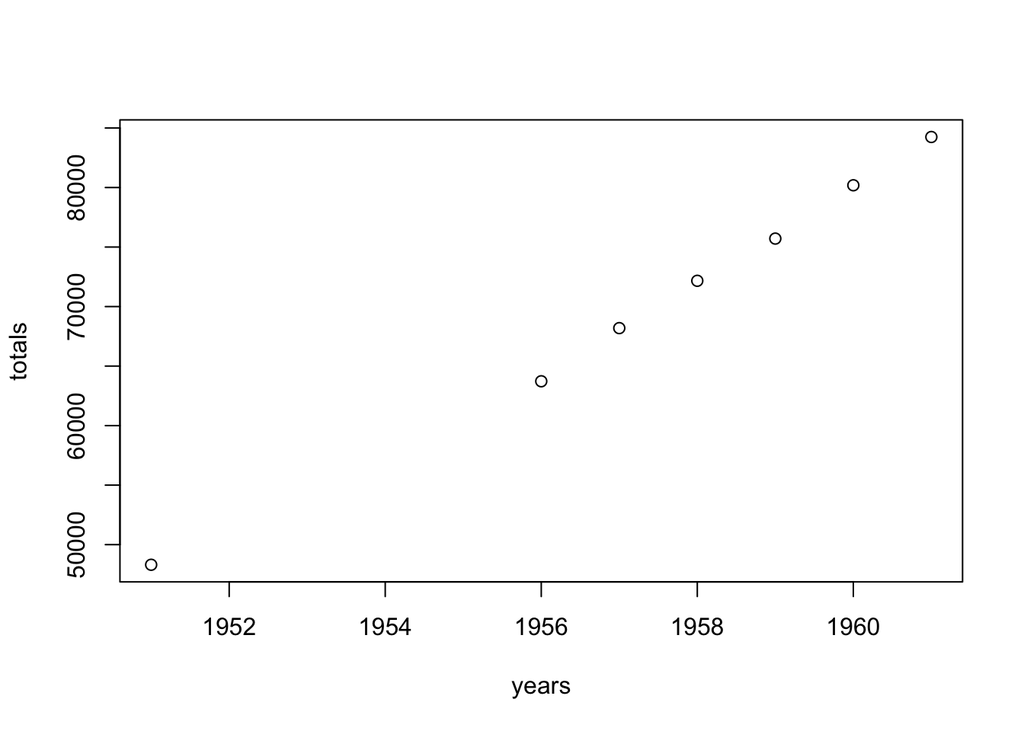

```r
plot(totals~years)
```

We can add a best-fit trendline if we are feeling saucy.

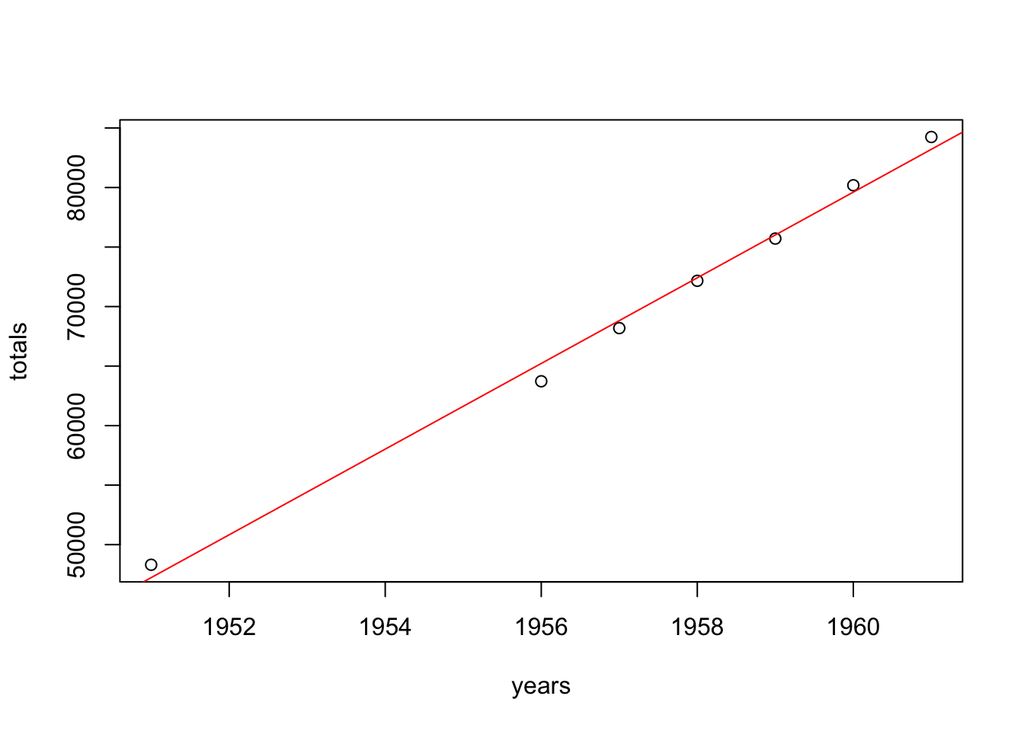

```r
plot(totals~years)
  abline(lm(totals~years), col="red")  #we'll do more of this soon;  lm is for linear model
```

## Reading-in and Writing-out data

Let’s go back to the *Pirate’s Guide*:

### read.table()

> If you have a .txt file that you want to read into R, use the `read.table()` function.

[output not shown]

```r
# Read a tab-delimited text file called mydata.txt
#  from the data folder in my working directory into
#  R and store as a new object called mydata

mydata <- read.table(file = 'mydata.txt',         # file is in my working directory
                     sep = '\t',                  # file is tab--delimited
                     header = TRUE,               # the first row of the data is a header row
                     stringsAsFactors = FALSE)    # do NOT convert strings (i.e., "words" or text) to factors (i.e., categorical variables)
```

### Reading files directly from a web URL

> A really neat feature of the `read.table()` function is that you can use it to load text files directly from the web (assuming you are online). To do this, just set the file path to the document’s web URL (beginning with `http://`). For example, I have a text file stored at `http://goo.gl/jTNf6P`. You can import and save this tab–delimited text file as a new object called `fromweb` as follows:

```r
# Read a text file from the web
fromweb <- read.table(file = 'http://goo.gl/jTNf6P',
                      sep = '\t',
                      header = TRUE)

# Print the result
fromweb
```

```
##            message randomdata
## 1 Congratulations!          1
## 2              you          2
## 3             just          3
## 4       downloaded          4
## 5             this          5
## 6            table          6
## 7             from          7
## 8              the          8
## 9             web!          9
```

> I think this is pretty darn cool. This means you can save your main data files on Dropbox or a web-server, and always have access to it from any computer by accessing it from its web URL.

#### Debugging

> When you run `read.table()`, you might receive an error like this:

> Error in file(file, “rt”) : cannot open the connection

> In addition: Warning message:

> In file(file, “rt”) : cannot open file ‘asdf’: No such file or directory

> If you receive this error, it’s likely because you either spelled the file name incorrectly, or did not specify the correct directory location in the `file` argument.

#### Excel, SPSS, and other data files

> A common question I hear is “How can I import an SPSS/Excel/… file into R?”. The first answer to this question I always give is “You shouldn’t”. **S**hitty **P**iece of **S**hitty **S**hit files can contain information like variable descriptions that R doesn’t know what to do with, and Excel files often contain something, like missing rows or cells with text instead of numbers, that can completely confuse R.

> Rather than trying to import SPSS or Excel files directly in R, I always recommend first exporting/saving the original SPSS or Excel files as text `.txt.` files – both SPSS and Excel have options to do this. Then, once you have exported the data to a `.txt` file, you can read it into R using `read.table()`.

> **Warning**: If you try to export an Excel file to a text file, it is a good idea to clean the file as much as you can first by, for example, deleting unnecessary columns, making sure that all numeric columns have numeric data, making sure the column names are simple (ie., single words without spaces or special characters). If there is anything ‘unclean’ in the file, then R may still have problems reading it, even after you export it to a text file.

> If you absolutely *have* to read a non-text file into R, check out the package called `foreign` (`install.packages("foreign")`). This package has functions for importing Stata, SAS and SPSS files directly into R. To read Excel files, try the package `xlsx` (`install.packages("xlsx")`). But again, in my experience it’s *always* better to convert such files to simple text files first, and then read them into R with `read.table()`.

> There are many functions other than `read.table()` for importing data. For example, the functions `read.csv` and `read.delim` are specific for importing comma-separated and tab-separated text files. In practice, these functions do the same thing as `read.table`, but they don’t require you to specify a `sep` argument. Personally, I always use `read.table()` because it always works and I don’t like trying to remember unnecessary functions.